# PCA & iForest Analysis

### By: Huan Shuo Hsu

## Objectives

We will be employing PCA and iForest techniques for the following:

- Detect any transactions that may be significantly different from the majority of normal transactions.
- Detect any transactions that show unusual spending behavior compared to peer transactions within the same dataset.
- Detect any transactions that stand out from the average (mean/median) transaction profile.
- Detect any transactions that are anomalous when evaluated against clusters of similar transaction groups (e.g., peer groups formed by PCA components).

We will not only pinpoint suspicious transactions but also evaluate which method provides more meaningful business insights in detecting potential fraud.

- Section 1: Data Preparation
  - Section 1.1: Libraries
  - Section 1.2: Data Preparation
  - Section 1.3: Feature Engineering
- Section 2: PCA Method
  - Section 2.1: Model Building
  - Section 2.2: Scoring & Threshold
  - Section 2.3: Score Distribution
  - Section 2.4: Normal vs Outlier Statistics
  - Section 2.5: Inspection
  - Section 2.6: Evaluation of Results
- Section 3: Isolation Forest Method
  - Section 3.1: Model Building
  - Section 3.2: Scoring & Threshold
  - Section 3.3: Score Distribution
  - Section 3.4: Normal vs Outlier Statistics
  - Section 3.5: Inspection
  - Section 3.6: Evaluation of Results

# Data Preparation

## Libraries

```python
import warnings
import numpy as np
import pandas as pd
import matplotlib.pyplot as plt
from pyod.models.pca import PCA
from pyod.models.iforest import IForest
from sklearn.preprocessing import StandardScaler
from sklearn.impute import SimpleImputer

warnings.filterwarnings("ignore", category=UserWarning)
```

## Data Preparation

We will take a look at the struction of our data and check what features we can work with.

```python
# Load data
df = pd.read_csv("data/purchase_credit_card.csv")

# Convert time columns
df["Transaction Date"] = pd.to_datetime(
    df["Transaction Date"], format="%m/%d/%Y %I:%M:%S %p", errors="coerce")

df["Posted Date"] = pd.to_datetime(
    df["Posted Date"], format="%m/%d/%Y %I:%M:%S %p", errors="coerce"
)

print(df.head())
```

```
   Year-Month  Agency Number                Agency Name Cardholder Last Name  \
0      201307           1000  OKLAHOMA STATE UNIVERSITY                Mason
1      201307           1000  OKLAHOMA STATE UNIVERSITY                Mason
2      201307           1000  OKLAHOMA STATE UNIVERSITY               Massey
3      201307           1000  OKLAHOMA STATE UNIVERSITY               Massey
4      201307           1000  OKLAHOMA STATE UNIVERSITY        Mauro-Herrera

  Cardholder First Initial                   Description  Amount  \
0                        C              GENERAL PURCHASE  890.00
1                        C                  ROOM CHARGES  368.96
2                        J              GENERAL PURCHASE  165.82
3                        T              GENERAL PURCHASE   96.39
4                        M  HAMMERMILL COPY PLUS COPY EA  125.96

           Vendor Transaction Date Posted Date  \
0           NACAS       2013-07-30  2013-07-31
1  SHERATON HOTEL       2013-07-30  2013-07-31
2  SEARS.COM 9300       2013-07-29  2013-07-31
3  WAL-MART #0137       2013-07-30  2013-07-31
4  STAPLES DIRECT       2013-07-30  2013-07-31

                        Merchant Category Code (MCC)
0        CHARITABLE AND SOCIAL SERVICE ORGANIZATIONS
1                                           SHERATON
2  DIRCT MARKETING/DIRCT MARKETERS--NOT ELSEWHERE...
3                    GROCERY STORES,AND SUPERMARKETS
4  STATIONERY, OFFICE SUPPLIES, PRINTING AND WRIT...
```

## Feature Engineering

We will create new numeric features to capture patterns:

- Day of week and hour of transaction (timing patterns)
- Delay between transaction and posting (potential fraud signal)
- Frequency encoding for Merchant Category Code (MCC) and Vendor (rare = more suspicious)

Handle missing values and scale features:

- We will replace missing values with median
- To ensures PCA is not dominated by one large-scale variable (Amount), we will standardize the values

```python
# Timing features
df["transaction_dayofweek"] = df["Transaction Date"].dt.dayofweek
df["transaction_hour"] = df["Transaction Date"].dt.hour
df["time_diff_days"] = (df["Posted Date"] - df["Transaction Date"]).dt.days

# Frequency encode MCC and Vendor
for col in ["Merchant Category Code (MCC)", "Vendor"]:
    freq = df[col].value_counts()
    df[col + "_freq"] = df[col].map(freq)

# Select numeric features (The ones we will be using from now on)
features = ["Amount", "transaction_dayofweek", "transaction_hour",
            "time_diff_days", "Merchant Category Code (MCC)_freq", "Vendor_freq"]
X = df[features]

# Handle missing values and scale features
imp = SimpleImputer(strategy="median")
X_imputed = imp.fit_transform(X)

scaler = StandardScaler()
X_scaled = scaler.fit_transform(X_imputed)
```

# PCA Method

Principal Component Analysis (PCA) is a technique that reduces data into a smaller set of principal components, which capture the main directions of variance. In anomaly detection, transactions that align well with these dominant patterns are considered normal, while those that fall far outside the component space are flagged as anomalies. By setting a contamination level, PCA automatically establishes a threshold to identify the most unusual transactions.

## Model Building

- **`n_components=5`**
  - Total number of principal components (PCs) to compute.
  - Captures variance across all features.
- **`n_selected_components=3`**
  - Top 3 principal components are used for anomaly scoring.
  - Outliers are identified by their distance in this reduced subspace.
- **`contamination=0.05`**
  - Assumes ~5% of the data are anomalies.
  - Sets the cutoff threshold for labeling outliers.
- **`standardization=False`**
  - Data was already standardized before fitting.
  - Avoids re-standardizing inside the PCA model.
- **`pca.threshold_`**
  - The anomaly score cutoff based on contamination.
  - Transactions with reconstruction error above this threshold are flagged as anomalies.

```python
pca = PCA(
    n_components=5,             # total PCs to compute
    n_selected_components=3,    # top PCs used for anomaly scoring
    contamination=0.05,         # assume 5% anomalies
    standardization=False       # already stdized in previous code
)
pca.fit(X_scaled)
```

```
PCA(contamination=0.05, copy=True, iterated_power='auto', n_components=5,
  n_selected_components=3, random_state=None, standardization=False,
  svd_solver='auto', tol=0.0, weighted=True, whiten=False)
```

## Scoring & Threshold

- **`pca.decision_function(X_scaled)`**
  - Calculates anomaly scores for each transaction.
  - Higher score = more likely to be an outlier.
  - Based on the reconstruction error from the top selected principal components.
- **`pca.predict(X_scaled)`**
  - Converts scores into binary labels:
    - `1` = anomaly (outlier)
    - `0` = normal (inlier)
  - Uses the contamination parameter (5%) to determine how many points to flag.
- **`pca.threshold_`**
  - The cutoff score for distinguishing anomalies from normals.
  - Derived automatically from the contamination setting.
  - Any transaction with a score above this threshold is labeled as an anomaly.

```python
df["pca_score"] = pca.decision_function(X_scaled)
df["pca_label"] = pca.predict(X_scaled)  # 1 = anomaly, 0 = normal

# Threshold used by PCA
print("The threshold for contamination=0.05:", pca.threshold_)
```

```
The threshold for contamination=0.05: 85.00829366845974
```

Interpretation:

- Any transaction with a PCA score > 85 is flagged as an anomaly.

## Score Distribution

- The histogram shows how scores are distributed, and the threshold splits normal vs anomalies.

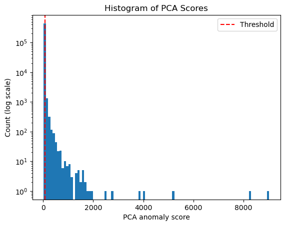

```python
plt.hist(df["pca_score"], bins=100)
plt.yscale("log")
plt.axvline(pca.threshold_, color="red", linestyle="--", label="Threshold")
plt.xlabel("PCA anomaly score")
plt.ylabel("Count (log scale)")
plt.title("Histogram of PCA Scores")
plt.legend()
plt.show()
```

Interpretaton:

- Most transactions have very low reconstruction error (close to 0).
- A small minority have large scores (hundreds or thousands) → these are the candidate anomalies.
- The red dashed line (pca.threshold_) is very close to zero. That’s because PCA sets the cutoff based on contamination rate (top 5% of scores).

## Normal vs Outlier Statistics

- We will compare anomaly group vs normal group by counts and averages of features.

```python
# Group assignment
df["Group"] = np.where(df["pca_score"] < pca.threshold_, "Normal", "Outlier")

# Count + %
cnt = df.groupby("Group")["pca_score"].count().reset_index().rename(columns={"pca_score":"Count"})
cnt["Count %"] = cnt["Count"] / cnt["Count"].sum() * 100
print(cnt)

# Compare means
stat = df.groupby("Group")[features].mean().round(2)
print(stat)
```

```
     Group   Count    Count %
0   Normal  420335  94.999977
1  Outlier   22123   5.000023
          Amount  transaction_dayofweek  transaction_hour  time_diff_days  \
Group
Normal    359.43                   2.31               0.0            1.82
Outlier  1670.74                   3.18               0.0            3.05

         Merchant Category Code (MCC)_freq  Vendor_freq
Group
Normal                             8905.21      1323.57
Outlier                           21390.80     11840.73
```

Interpretation:

- **Proportion of anomalies:**
  - PCA flagged about **22,123 transactions (~5%)** as anomalies.
  - This aligns with the contamination setting of 5%, making it directly comparable with Isolation Forest.
- **Transaction Amounts:**
  - Outliers average **$1,670**, compared to **$359** for normal transactions.
  - PCA is clearly capturing unusually **high-value transactions** as suspicious.
- **Timing (day of week / hour):**
  - Outliers occur on a later average **day of week (3.18)** vs normals (2.31).
  - Transaction hour again averages to 0 for both groups, showing little distinction here (likely default values in the dataset).
- **Posting delay (`time_diff_days`):**
  - Outliers have a longer posting delay (**3.05 days**) than normals (**1.82 days**).
  - Delays may indicate riskier or atypical processing paths.
- **Merchant Category Code (MCC) frequency:**
  - Outliers are tied to **much more common MCC codes (21,391 vs 8,905)**.
  - Suggests anomalies are concentrated in high-volume categories, possibly dominated by certain merchant types.
- **Vendor frequency:**
  - Outliers are linked to vendors with **very high transaction counts (11,841 vs 1,324)**.
  - Indicates PCA is flagging bulk/high-volume vendor activity as anomalous.

**Summary:**  
PCA anomalies are driven by **large amounts**, **longer posting delays**, and **concentration in frequent vendors/categories**.  
PCA shows similar directional findings (high amounts, delays, frequent vendors), but may emphasize variance structure more strongly, making it particularly sensitive to **large-value corporate/vendor payments**.

## Inspection

- We will list the top flagged anomalies by score

```
            Amount                 Vendor  \
218925  1903858.37     PAYMENT ADJUSTMENT
212076  1750379.98     PAYMENT ADJUSTMENT
251918  1089180.00   PELCO STRUCTURAL LLC
365832   855343.00   PELCO STRUCTURAL LLC
251488   814934.76        EMC CORPORATION
31364       -34.82      UNIVERSITEIT GENT
329682      -30.00              AT&T DATA
329683      -30.00              AT&T DATA
251616   403490.75        EMC CORPORATION
367166   373150.26  TK CONSTRUCTIO US LLC

                             Merchant Category Code (MCC)    pca_score  \
218925                                         OTHER FEES  9019.107590
212076                                         OTHER FEES  8289.931066
```

[output cut: 20 more lines]

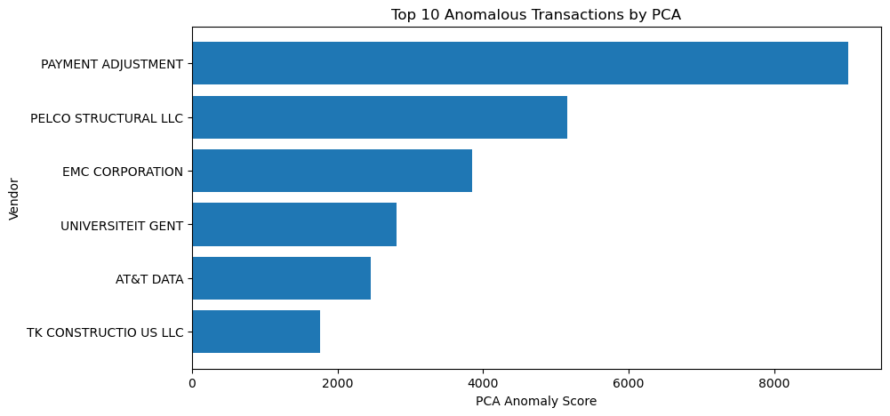

```python
top = df.sort_values("pca_score", ascending=False).head(10)
print(top[["Amount","Vendor","Merchant Category Code (MCC)","pca_score","pca_label"]])

# summary chart
plt.figure(figsize=(10,5))
plt.barh(top_display["Vendor"], top_display["pca_score"])
plt.xlabel("PCA Anomaly Score")
plt.ylabel("Vendor")
plt.title("Top 10 Anomalous Transactions by PCA")
plt.gca().invert_yaxis()
plt.show()
```

Interpretation:

- **Payment Adjustments ($1.9M, $1.75M):**
  - These dominate the anomaly list, with extremely high values and unique “Other Fees” MCC codes.
  - PCA is very sensitive to such **variance-extreme transactions**, and these adjustments are far outside the normal scale of purchases.
- **Pelco Structural LLC ($1.09M, $855K, Commercial Equipment):**
  - Large-scale vendor payments for commercial equipment.
  - Transactions of this magnitude are rare in the dataset and easily flagged as anomalies by PCA.
- **EMC Corporation ($815K, $403K, Computers & Equipment):**
  - Multiple high-value purchases for IT hardware/software.
  - Highlights PCA’s ability to catch **repeat big-ticket transactions** within the same vendor.
- **Universiteit Gent (Refund, –$34.82):**
  - A small **negative transaction (credit/refund)**, very unusual compared to the large positive purchases.
  - Shows PCA’s strength: it not only captures huge payments but also **tiny reversals/refunds** that deviate from the variance pattern.
- **AT&T Data (Refunds, –$30.00 each):**
  - Similar to Universiteit Gent, these are unusual small refunds within telecommunications.
  - Reinforces that PCA detects **both ends of the spectrum — extreme highs and small rare lows**.
- **TK Construction US LLC ($373K, General Contractors):**
  - High-value vendor payment in the construction category.
  - Construction services appear much less frequently than regular purchases, making them stand out.

### Summary

PCA flagged:

- **Very large adjustments and vendor purchases** (Payment Adjustment, Pelco Structural, EMC, Construction).
- **Unusual small negative transactions (refunds)**, which are structurally very different from typical payments.

## Evaluation of Results

- PCA effectively captured **both ends of the spectrum**:
  - Extremely large transactions (e.g., multi-million dollar adjustments, high-value corporate purchases).
  - Unusually small negative transactions (e.g., refunds and credits).
- This dual sensitivity makes PCA powerful for detecting **variance-driven anomalies** across different scales.
- However, PCA can sometimes overemphasize variance-heavy vendors, leading to clusters of similar anomalies (e.g., multiple large corporate purchases).

**Conclusion:** PCA is better at finding **a wide variety of anomalies**, including both massive payments and rare small reversals, making it highly flexible but potentially noisier in results.

# iForest Method

Isolation Forest detects anomalies by randomly partitioning the feature space with many binary trees. Points that are easy to isolate (short average path length across trees) are likely outliers; typical points require more splits. We keep the same contamination (5%) as PCA so the two methods are directly comparable in counts and thresholds.

# Model Building

- **`decision_function(X_scaled)`**
  - Calculates raw anomaly scores for each transaction.
  - Higher score = more likely anomaly.
  - Based on the average path length in the isolation trees.
- **`predict(X_scaled)`**
  - Converts scores into binary labels:
    - `1` = anomaly (outlier)
    - `0` = normal (inlier)
  - Uses `contamination=0.05` so ~5% of transactions are flagged.

```python
iforest = IForest(
    n_estimators=200,       # more trees = more stable scores
    max_samples='auto',     # min(256, n_samples) per tree
    contamination=0.05,     # ~5% anomalies to match PCA
    max_features=1.0,       # use all features (try 0.8 for extra randomness)
    random_state=42         # reproducibility for your report
)

# Fit on the same engineered, imputed, standardized matrix used for PCA
iforest.fit(X_scaled)
```

```
IForest(behaviour='old', bootstrap=False, contamination=0.05,
    max_features=1.0, max_samples='auto', n_estimators=200, n_jobs=1,
    random_state=42, verbose=0)
```

## Scoring & Threshold

- **`iforest.threshold_`**
  - Cutoff score used to split anomalies vs normals.
  - For iForest in PyOD this is usually **0.0**, since scores are normalized around zero.
  - Interpretation:
    - Score < 0 → normal
    - Score > 0 → anomaly

```python
# Scores & labels
df["iforest_score"] = iforest.decision_function(X_scaled)  # higher = more anomalous
df["iforest_label"] = iforest.predict(X_scaled)            # 1 = anomaly, 0 = normal

# Threshold chosen to satisfy contamination level
print("Isolation Forest threshold (contamination=0.05):", iforest.threshold_)
```

```
Isolation Forest threshold (contamination=0.05): 0.0
```

## Score Distribution

- Plots the distribution of anomaly scores assigned by Isolation Forest.
- The **red dashed line** shows the decision threshold (usually 0.0).
  - **Scores < 0 → normal transactions.**
  - **Scores > 0 → anomalies.**
- Confirms that about 5% of points (set by contamination) fall to the right of the threshold.

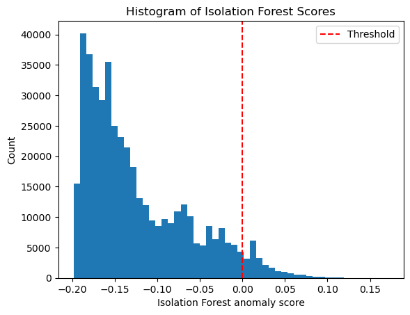

```python
plt.hist(df["iforest_score"], bins=50)
plt.axvline(iforest.threshold_, color='red', linestyle='--', label='Threshold')
plt.xlabel("Isolation Forest anomaly score")
plt.ylabel("Count")
plt.title("Histogram of Isolation Forest Scores")
plt.legend()
plt.show()
```

Intepretation:

- Most transactions (≈95%) have strongly negative scores and are consistently normal.
- Outliers are the small tail above zero — transactions that Isolation Forest found easy to isolate because they have unusual amounts, vendors, or timing.
- This matches expectations: fraud is rare, and anomalies are only a small sliver of the dataset.

## Normal vs Outlier Statistics

- Splits transactions into **Normal** and **Outlier** groups using the threshold.
- Counts how many transactions are in each group, plus their percentage of the dataset.
- Calculates average values of key features (e.g., Amount, timing, Vendor/MCC frequency).
- Highlights how anomalies differ — e.g., higher amounts, odd posting delays, or rare vendors.

```python
# Assign group labels
df["iforest_group"] = np.where(df["iforest_score"] < iforest.threshold_, "Normal", "Outlier")

# Count + percentage of each group
cnt_iforest = df.groupby("iforest_group")["iforest_score"].count().reset_index().rename(columns={"iforest_score":"Count"})
cnt_iforest["Count %"] = cnt_iforest["Count"] / cnt_iforest["Count"].sum() * 100
print(cnt_iforest)

# Compare averages of selected features
stat_iforest = df.groupby("iforest_group")[features].mean().round(2)
print(stat_iforest)
```

```
  iforest_group   Count    Count %
0        Normal  420323  94.997265
1       Outlier   22135   5.002735
                Amount  transaction_dayofweek  transaction_hour  \
iforest_group
Normal          298.24                   2.31               0.0
Outlier        2831.79                   3.20               0.0

               time_diff_days  Merchant Category Code (MCC)_freq  Vendor_freq
iforest_group
Normal                   1.82                            9084.76      1454.14
Outlier                  2.91                           17974.46      9355.54
```

Intepretation:

- **Proportion of anomalies:**
  - Isolation Forest flagged about **22,135 transactions (~5%)** as anomalies.
  - This matches the contamination setting of 5%, ensuring consistency with PCA.
- **Transaction Amounts:**
  - Outliers have an **average amount of $2,831**, compared to **$298** for normal transactions.
  - This shows that anomalies are heavily skewed toward unusually large transaction values.
- **Timing (day of week / hour):**
  - Outliers tend to occur on a slightly later **day of the week (avg 3.2)** vs normals (avg 2.3).
  - Transaction hour averages to 0 for both groups, suggesting midnight defaults in the dataset (so hour may not be informative here).
- **Posting delay (`time_diff_days`):**
  - Outliers have a longer average posting delay (**2.91 days**) vs normals (**1.82 days**).
  - Delayed posting can be suspicious (e.g., manual review, unusual processing).
- **Merchant Category Code (MCC) frequency:**
  - Outliers are associated with **more frequent MCC codes (17,974 vs 9,085)**.
  - Suggests anomalies concentrate in high-volume merchant categories.
- **Vendor frequency:**
  - Outliers are also tied to **vendors with very high transaction counts (9,356 vs 1,454)**.
  - This may indicate large institutional vendors or recurring bulk payments being treated as anomalies due to magnitude and repetition.

### Summary:

Isolation Forest anomalies are characterized by **much higher amounts**, **longer posting delays**, and **concentration in frequent vendors/categories**. These differ from PCA anomalies, which also captured unusually small or rare transactions.

## Inspection

- Sorts all transactions by **Isolation Forest anomaly score** (descending).
- Displays the **top 10 most anomalous transactions** with their amount, vendor, MCC, score, and label.
- Produces a **bar chart** showing which vendors are most strongly flagged.
- Helps identify specific merchants or payments that Isolation Forest considers highly suspicious.

```
            Amount                    Vendor  \
92361      4907.22                Amazon.com
231549     9500.00              DENOVIX, INC
218925  1903858.37        PAYMENT ADJUSTMENT
212076  1750379.98        PAYMENT ADJUSTMENT
97138      9675.00                   STAPLES
79762     45093.10               WW GRAINGER
248973    45573.00               WW GRAINGER
248974    37942.50               WW GRAINGER
365095    99000.00  ACOUSTIC EMISSION CONSUL
246477   343148.50        PAYMENT ADJUSTMENT

                             Merchant Category Code (MCC)  iforest_score  \
92361                                         BOOK STORES       0.170938
231549  DENTAL/LABORATORY/MEDICAL/OPHTHALMIC HOSP EQIP...       0.164848
```

[output cut: 20 more lines]

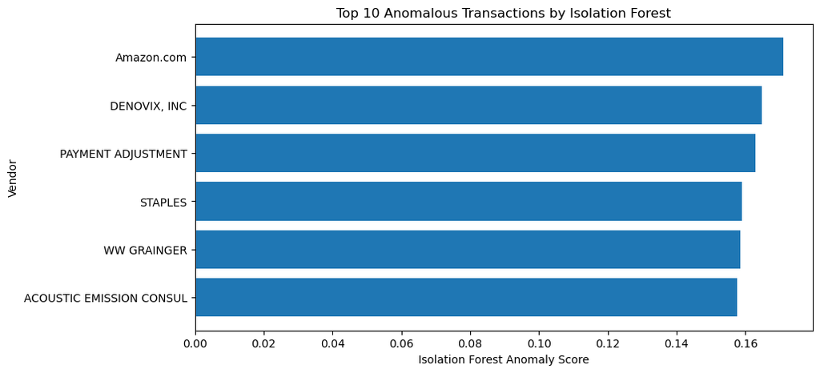

```python
# Top 10 anomalies by iForest scor
top_iforest = df.sort_values("iforest_score", ascending=False).head(10)

print(top_iforest[["Amount","Vendor","Merchant Category Code (MCC)","iforest_score","iforest_label"]])

# Summary bar chart
plt.figure(figsize=(10,5))
plt.barh(top_iforest["Vendor"], top_iforest["iforest_score"])
plt.xlabel("Isolation Forest Anomaly Score")
plt.ylabel("Vendor")
plt.title("Top 10 Anomalous Transactions by Isolation Forest")
plt.gca().invert_yaxis()  # highest score at top
plt.show()
```

Interpretation:

- **Amazon.com ($4,907):**
  - Amazon is a familiar vendor, but this unusually high-value purchase stands out.
  - iForest isolates it because consumer-oriented vendors rarely have such large charges in this dataset.
- **Denovix, Inc. ($9,500, Medical/Lab Equipment):**
  - Specialized scientific supplier with a relatively rare, large purchase.
  - Transactions from niche vendors at this scale are atypical and therefore flagged.
- **Payment Adjustments ($1.9M, $1.75M, $343K):**
  - Extremely high-value adjustments dominate the anomalies.
  - These are structurally different from normal purchases and consistently marked as suspicious by iForest.
- **Staples ($9,675, Office Supplies):**
  - Vendor is common, but the transaction size is **much higher** than typical office supply purchases.
  - Suggests the anomaly comes from transaction scale rather than vendor rarity.
- **WW Grainger ($45K, $45.5K, $37.9K, Industrial Supplies):**
  - Multiple large purchases from the same industrial vendor.
  - Repetition of high-value procurement orders marks these as outliers compared to typical transactions.
- **Acoustic Emission Consulting ($99K, Business Services):**
  - Rare, specialized consulting service with a very large payment.
  - Uncommon vendor type and high dollar amount both contribute to the anomaly score.

### Summary

Isolation Forest highlighted a mix of **extreme transaction amounts (millions in adjustments)** and **high-value vendor payments** (Amazon, Staples, Grainger, consulting). Unlike PCA, which also picked up on unusual small refunds, iForest focuses heavily on **large-scale or structurally uncommon transactions**. This makes it especially effective at flagging big corporate payments and specialized vendor charges.

## Evaluation of Results

- Isolation Forest primarily flagged **structurally unusual and high-value transactions**:
  - Very large adjustments (>$1M).
  - High-value vendor purchases (Amazon, Staples, WW Grainger, consulting services).
- Unlike PCA, iForest did **not capture small-scale refunds**, instead focusing strongly on magnitude and vendor patterns.
- The method excels at isolating **transactions that deviate sharply in scale and structure** from the majority.

**Conclusion:** Isolation Forest is better at finding **large-scale, high-impact anomalies** that are most likely to represent financial risk, but it may miss subtle anomalies like small credits or rare reversals.